# Repeat CIA 1 LAB Component

## 1. Load, inspect, and verify data types

```python
import numpy as np
import pandas as pd
import matplotlib.pyplot as plt
import seaborn as sns
from IPython.display import display

sns.set_theme(style="whitegrid")
pd.set_option("display.max_columns", None)
raw = pd.read_csv("housing.csv")
df = pd.DataFrame({
    "MedInc": raw.median_income,
    "HouseAge": raw.housing_median_age,
    "AveRooms": raw.total_rooms / raw.households,
    "AveBedrms": raw.total_bedrooms / raw.households,
    "Population": raw.population,
    "AveOccup": raw.population / raw.households,
    "Latitude": raw.latitude,
    "Longitude": raw.longitude,
    "MedHouseVal": raw.median_house_value / 100000,
})
assert len(df) == len(raw) and df.shape[1] == 9
```

```python
display(df.head(10))
print("Continuous numerical features:", df.columns.drop("MedHouseVal").tolist())
print("Target: MedHouseVal (median house value in $100,000 units)")
display(df.dtypes.rename("dtype").to_frame())
print("All analysis columns are numeric; ocean_proximity is categorical.")
```

|  | MedInc | HouseAge | AveRooms | AveBedrms | Population | AveOccup | Latitude | Longitude | MedHouseVal |
| --- | --- | --- | --- | --- | --- | --- | --- | --- | --- |
| 0 | 8.3252 | 41.0 | 6.984127 | 1.023810 | 322.0 | 2.555556 | 37.88 | -122.23 | 4.526 |
| 1 | 8.3014 | 21.0 | 6.238137 | 0.971880 | 2401.0 | 2.109842 | 37.86 | -122.22 | 3.585 |
| 2 | 7.2574 | 52.0 | 8.288136 | 1.073446 | 496.0 | 2.802260 | 37.85 | -122.24 | 3.521 |
| 3 | 5.6431 | 52.0 | 5.817352 | 1.073059 | 558.0 | 2.547945 | 37.85 | -122.25 | 3.413 |
| 4 | 3.8462 | 52.0 | 6.281853 | 1.081081 | 565.0 | 2.181467 | 37.85 | -122.25 | 3.422 |
| 5 | 4.0368 | 52.0 | 4.761658 | 1.103627 | 413.0 | 2.139896 | 37.85 | -122.25 | 2.697 |
| 6 | 3.6591 | 52.0 | 4.931907 | 0.951362 | 1094.0 | 2.128405 | 37.84 | -122.25 | 2.992 |
| 7 | 3.1200 | 52.0 | 4.797527 | 1.061824 | 1157.0 | 1.788253 | 37.84 | -122.25 | 2.414 |
| 8 | 2.0804 | 42.0 | 4.294118 | 1.117647 | 1206.0 | 2.026891 | 37.84 | -122.26 | 2.267 |
| 9 | 3.6912 | 52.0 | 4.970588 | 0.990196 | 1551.0 | 2.172269 | 37.84 | -122.25 | 2.611 |

```
Continuous numerical features: ['MedInc', 'HouseAge', 'AveRooms', 'AveBedrms', 'Population', 'AveOccup', 'Latitude', 'Longitude']
Target: MedHouseVal (median house value in $100,000 units)
```

|  | dtype |
| --- | --- |
| MedInc | float64 |
| HouseAge | float64 |
| AveRooms | float64 |
| AveBedrms | float64 |
| Population | float64 |
| AveOccup | float64 |
| Latitude | float64 |
| Longitude | float64 |
| MedHouseVal | float64 |

```
All analysis columns are numeric; ocean_proximity is categorical.
```

## 2. Descriptive statistics, variance, and skewness

|  | count | mean | std | min | 25% | 50% | 75% | max |
| --- | --- | --- | --- | --- | --- | --- | --- | --- |
| MedInc | 20640.0 | 3.870671 | 1.899822 | 0.499900 | 2.563400 | 3.534800 | 4.743250 | 15.000100 |
| HouseAge | 20640.0 | 28.639486 | 12.585558 | 1.000000 | 18.000000 | 29.000000 | 37.000000 | 52.000000 |
| AveRooms | 20640.0 | 5.429000 | 2.474173 | 0.846154 | 4.440716 | 5.229129 | 6.052381 | 141.909091 |
| AveBedrms | 20433.0 | 1.097062 | 0.476104 | 0.333333 | 1.006029 | 1.048889 | 1.099631 | 34.066667 |
| Population | 20640.0 | 1425.476744 | 1132.462122 | 3.000000 | 787.000000 | 1166.000000 | 1725.000000 | 35682.000000 |
| AveOccup | 20640.0 | 3.070655 | 10.386050 | 0.692308 | 2.429741 | 2.818116 | 3.282261 | 1243.333333 |
| Latitude | 20640.0 | 35.631861 | 2.135952 | 32.540000 | 33.930000 | 34.260000 | 37.710000 | 41.950000 |
| Longitude | 20640.0 | -119.569704 | 2.003532 | -124.350000 | -121.800000 | -118.490000 | -118.010000 | -114.310000 |
| MedHouseVal | 20640.0 | 2.068558 | 1.153956 | 0.149990 | 1.196000 | 1.797000 | 2.647250 | 5.000010 |

|  | sample_variance |
| --- | --- |
| Population | 1.282470e+06 |
| HouseAge | 1.583963e+02 |
| AveOccup | 1.078700e+02 |
| AveRooms | 6.121533e+00 |
| Latitude | 4.562293e+00 |
| Longitude | 4.014139e+00 |
| MedInc | 3.609323e+00 |
| MedHouseVal | 1.331615e+00 |
| AveBedrms | 2.266751e-01 |

```
Largest variance: Population (1,282,470.46); variance is scale-dependent.
```

|  | mean | median |
| --- | --- | --- |
| MedHouseVal | 2.068558 | 1.7970 |
| MedInc | 3.870671 | 3.5348 |

```
Both means exceed their medians, suggesting positive (right) skew.
```

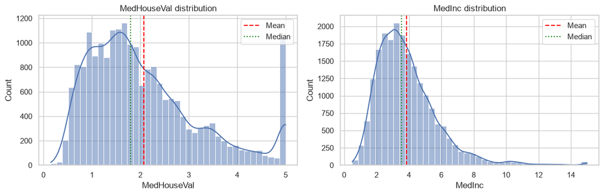

```python
display(df.describe().T)
variances = df.var().sort_values(ascending=False)
display(variances.rename("sample_variance").to_frame())
print(f"Largest variance: {variances.index[0]} ({variances.iloc[0]:,.2f}); variance is scale-dependent.")
comparison = df[["MedHouseVal", "MedInc"]].agg(["mean", "median"]).T
display(comparison)
print("Both means exceed their medians, suggesting positive (right) skew.")

fig, axes = plt.subplots(1, 2, figsize=(12, 4))
for ax, column in zip(axes, ["MedHouseVal", "MedInc"]):
    sns.histplot(df[column], bins=40, kde=True, ax=ax)
    ax.axvline(df[column].mean(), color="red", linestyle="--", label="Mean")
    ax.axvline(df[column].median(), color="green", linestyle=":", label="Median")
    ax.set_title(f"{column} distribution")
    ax.legend()
plt.tight_layout(); plt.show()
```

## 3. Missing values and missingness mechanisms

```python
missing = pd.DataFrame({"missing_count": df.isna().sum(), "missing_percent": df.isna().mean() * 100})
total_missing = missing.missing_count.sum()
display(missing)
print(f"Total missing cells: {total_missing} ({total_missing / df.size * 100:.3f}% of all cells)")
```

|  | missing_count | missing_percent |
| --- | --- | --- |
| MedInc | 0 | 0.000000 |
| HouseAge | 0 | 0.000000 |
| AveRooms | 0 | 0.000000 |
| AveBedrms | 207 | 1.002907 |
| Population | 0 | 0.000000 |
| AveOccup | 0 | 0.000000 |
| Latitude | 0 | 0.000000 |
| Longitude | 0 | 0.000000 |
| MedHouseVal | 0 | 0.000000 |

```
Total missing cells: 207 (0.111% of all cells)
```

AveRooms contained no missing values. AveBedrms contained 207 missing values which was about 1% of the dataset. Since the missing values are below 5%, I would keep the column and impute the missing values with median.

MAR Example : Price evaluations may be missing more often for inland homes, while location is observed. MNAR example: Owners of unusually expensive homes may withhold their valuations, so missingness depends on the unreported price itself. MNAR needs sensitivity analysis because ordinary imputation can remain biased.

## 4. Spatial, income-bin, and scatter plots

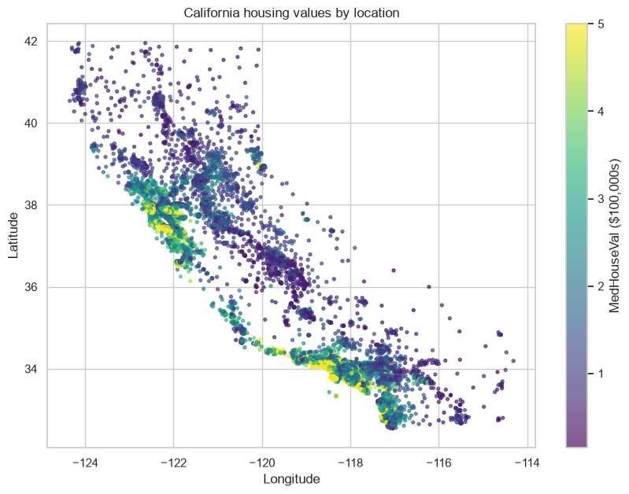

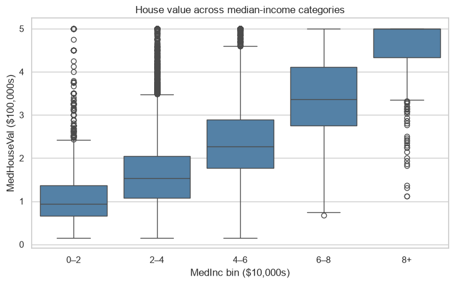

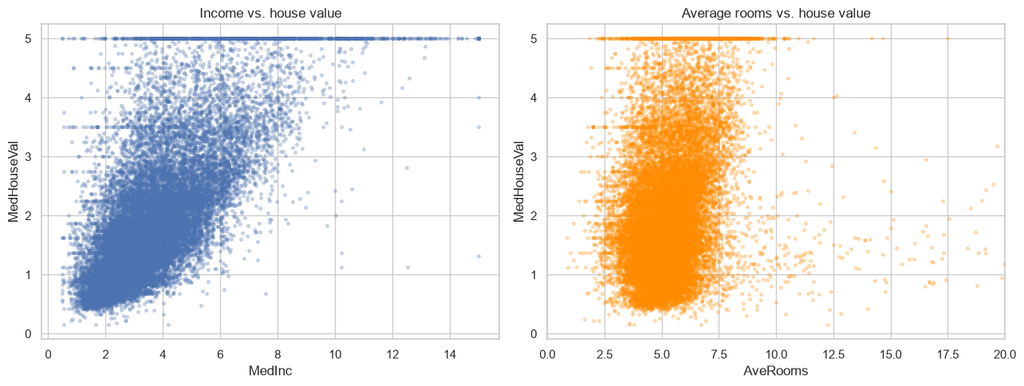

```python
plt.figure(figsize=(10, 7))
points = plt.scatter(df.Longitude, df.Latitude, c=df.MedHouseVal, cmap="viridis", s=8, alpha=.65)
plt.colorbar(points, label="MedHouseVal ($100,000s)")
plt.title("California housing values by location")
plt.xlabel("Longitude"); plt.ylabel("Latitude"); plt.show()

income_bin = pd.cut(df.MedInc, [0, 2, 4, 6, 8, np.inf], labels=["0–2", "2–4", "4–6", "6–8", "8+"], include_lowest=True)
plt.figure(figsize=(9, 5))
sns.boxplot(x=income_bin, y=df.MedHouseVal, color="steelblue")
plt.title("House value across median-income categories")
plt.xlabel("MedInc bin ($10,000s)"); plt.ylabel("MedHouseVal ($100,000s)"); plt.show()

fig, axes = plt.subplots(1, 2, figsize=(13, 5))
axes[0].scatter(df.MedInc, df.MedHouseVal, s=7, alpha=.25)
axes[0].set(xlabel="MedInc", ylabel="MedHouseVal", title="Income vs. house value")
axes[1].scatter(df.AveRooms, df.MedHouseVal, s=7, alpha=.25, color="darkorange")
axes[1].set(xlabel="AveRooms", ylabel="MedHouseVal", title="Average rooms vs. house value", xlim=(0, 20))
plt.tight_layout(); plt.show()
```

**Interpretation:** Coastal areas are generally more expensive. House value rises with income, while average rooms has a weaker relationship. The band near 5 is the dataset's price cap.

## 5. Pearson correlation matrix

|  | MedInc | HouseAge | AveRooms | AveBedrms | Population | AveOccup | Latitude | Longitude | MedHouseVal |
| --- | --- | --- | --- | --- | --- | --- | --- | --- | --- |
| MedInc | 1.000 | -0.119 | 0.327 | -0.062 | 0.005 | 0.019 | -0.080 | -0.015 | 0.688 |
| HouseAge | -0.119 | 1.000 | -0.153 | -0.078 | -0.296 | 0.013 | 0.011 | -0.108 | 0.106 |
| AveRooms | 0.327 | -0.153 | 1.000 | 0.849 | -0.072 | -0.005 | 0.106 | -0.028 | 0.152 |
| AveBedrms | -0.062 | -0.078 | 0.849 | 1.000 | -0.067 | -0.006 | 0.070 | 0.013 | -0.047 |
| Population | 0.005 | -0.296 | -0.072 | -0.067 | 1.000 | 0.070 | -0.109 | 0.100 | -0.025 |
| AveOccup | 0.019 | 0.013 | -0.005 | -0.006 | 0.070 | 1.000 | 0.002 | 0.002 | -0.024 |
| Latitude | -0.080 | 0.011 | 0.106 | 0.070 | -0.109 | 0.002 | 1.000 | -0.925 | -0.144 |
| Longitude | -0.015 | -0.108 | -0.028 | 0.013 | 0.100 | 0.002 | -0.925 | 1.000 | -0.046 |
| MedHouseVal | 0.688 | 0.106 | 0.152 | -0.047 | -0.025 | -0.024 | -0.144 | -0.046 | 1.000 |

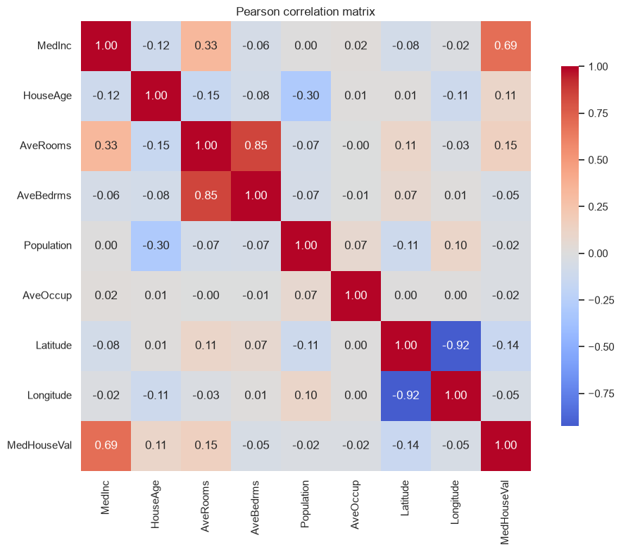

|  | r with MedHouseVal |
| --- | --- |
| MedInc | 0.688075 |
| AveRooms | 0.151948 |
| HouseAge | 0.105623 |

```python
corr = df.corr()
display(corr.round(3))
plt.figure(figsize=(10, 8))
sns.heatmap(corr, cmap="coolwarm", center=0, annot=True, fmt=".2f", square=True, cbar_kws={"shrink": .8})
plt.title("Pearson correlation matrix"); plt.tight_layout(); plt.show()
display(corr.loc[["MedInc", "AveRooms", "HouseAge"], ["MedHouseVal"]].rename(columns={"MedHouseVal": "r with MedHouseVal"}))
```

- MedInc has the strongest positive correlation with price (about 0.69).
- AveRooms (about 0.15) and HouseAge (about 0.11) are weakly positive. -Non encoded categorical features cannot be used in Pearson's corerelation matrix as Correlation is not causation. Pearson correlation requires numeric values with meaningful arithmetic; raw category names cannot be used, and arbitrary integer labels would create a false order.

## 6. IQR outlier detection

```python
outlier_rows = []
for column in ["AveRooms", "Population", "AveOccup", "MedHouseVal"]:
    q1, q3 = df[column].quantile([.25, .75])
    iqr = q3 - q1
    lower, upper = q1 - 1.5 * iqr, q3 + 1.5 * iqr
    count = ((df[column] < lower) | (df[column] > upper)).sum()
    outlier_rows.append([column, q1, q3, iqr, lower, upper, count, count / len(df) * 100])
outliers = pd.DataFrame(outlier_rows, columns=["feature", "Q1", "Q3", "IQR", "lower_bound", "upper_bound", "outlier_count", "outlier_percent"]).set_index("feature")
assert outliers.outlier_percent.between(0, 100).all()
display(outliers.round(3))
```

| feature | Q1 | Q3 | IQR | lower_bound | upper_bound | outlier_count | outlier_percent |
| --- | --- | --- | --- | --- | --- | --- | --- |
| AveRooms | 4.441 | 6.052 | 1.612 | 2.023 | 8.470 | 511 | 2.476 |
| Population | 787.000 | 1725.000 | 938.000 | -620.000 | 3132.000 | 1196 | 5.795 |
| AveOccup | 2.430 | 3.282 | 0.853 | 1.151 | 4.561 | 711 | 3.445 |
| MedHouseVal | 1.196 | 2.647 | 1.451 | -0.981 | 4.824 | 1071 | 5.189 |

IQR flags unusual values, not automatic errors. Extreme AveRooms values may represent genuine luxury or low-density properties, but they can also result from incorrect totals or division by very few households. Extreme MedHouseVal values may be genuine expensive homes

## 7. Synthesis and recommendations

```python
coastal_summary = raw.groupby("ocean_proximity").median_house_value.agg(["count", "mean", "median"]).sort_values("mean", ascending=False)
display(coastal_summary.round(0))
print(f"Correlation between AveRooms and AveBedrms: {df.AveRooms.corr(df.AveBedrms):.3f}")
display(corr.MedHouseVal.drop("MedHouseVal").sort_values(key=abs, ascending=False).rename("correlation_with_target").to_frame())
```

| ocean_proximity | count | mean | median |
| --- | --- | --- | --- |
| ISLAND | 5 | 380440.0 | 414700.0 |
| NEAR BAY | 2290 | 259212.0 | 233800.0 |
| NEAR OCEAN | 2658 | 249434.0 | 229450.0 |
| <1H OCEAN | 9136 | 240084.0 | 214850.0 |
| INLAND | 6551 | 124805.0 | 108500.0 |

```
Correlation between AveRooms and AveBedrms: 0.849
```

|  | correlation_with_target |
| --- | --- |
| MedInc | 0.688075 |
| AveRooms | 0.151948 |
| Latitude | -0.144160 |
| HouseAge | 0.105623 |
| AveBedrms | -0.046739 |
| Longitude | -0.045967 |
| Population | -0.024650 |
| AveOccup | -0.023737 |

- Coastal groups have higher typical prices than inland groups. The five island rows are too less to make an interpretation.
- AveRooms and AveBedrms are strongly correlated (0.85).
- In linear regression this can inflate coefficient uncertainty and make individual coefficients unstable. Keep one feature or use regularization.
- MedInc is the strongest single linear predictor but location also matters.
- Use training-set median imputation, one-hot encode ocean_proximity, validate by geographic groups, inspect outliers and the capped target, and compare a linear baseline with a tree model.